# Effects of Urbanization on Barn Swallow Body Size

Winson Liu

2024-10-23

# Introduction

This study investigates how urbanization affects the body size of Barn Swallows (*Hirundo rustica gutturalis*) in China. Data was collected from 128 sites at varying stages of urbanization, measuring physiological characteristics (body mass and wing length) of breeding individuals. The unit of observation is a singular swallow.

# Methods

```r
# Load required packages
library(tidyverse)
library(car)
library(effectsize)
library(cowplot)
library(emmeans)
library(DHARMa)  # For GLM diagnostics

# Set contrasts
options(contrasts=c("contr.poly","contr.sum"))
```

```r
# Import data
BodySize_data <- read.csv("/Users/winny/Downloads/doi_10-10/Liu_Winson Dataset/Liu_Winson Dataset/BodySize_data.csv", stringsAsFactors=TRUE)

# Check for missing values
sapply(BodySize_data[c("sex", "urbanization", "body.mass", "wing.length")],
       function(x) sum(is.na(x)))
```

```
##          sex urbanization    body.mass  wing.length
##            0            0            0            0
```

# Analysis 1: Sex and Urbanization Effects

Biological Question: Does urbanization affect body size differently between different sexes?

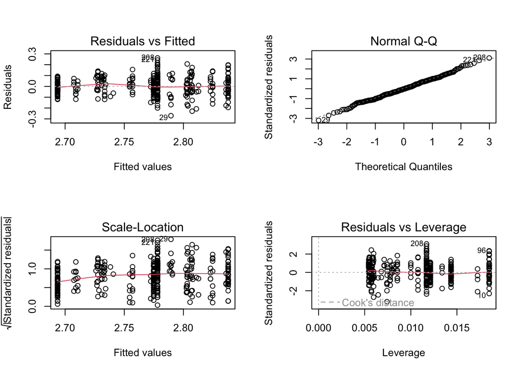

```r
# Body mass models
mod1 = lm(body.mass ~ urbanization * sex, data=BodySize_data)
modlog1 = lm(log(body.mass) ~ urbanization*sex, data=BodySize_data)

# Wing length models
mod2 = lm(wing.length ~ urbanization * sex, data=BodySize_data)
modglm2 = glm(wing.length ~ urbanization*sex, data=BodySize_data, family="Gamma")

# Check assumptions
par(mfrow=c(2,2))
plot(modlog1)
```

```r
shapiro.test(modlog1$residuals)
```

```
##
##  Shapiro-Wilk normality test
##
## data:  modlog1$residuals
## W = 0.99718, p-value = 0.7962
```

```r
# Results
Anova(modlog1, type=3)
```

```
## Anova Table (Type III tests)
##
## Response: log(body.mass)
##                  Sum Sq  Df    F value    Pr(>F)
## (Intercept)      958.72   1 1.3234e+05 < 2.2e-16 ***
## urbanization       0.30   1 4.0729e+01 5.466e-10 ***
## sex                0.12   1 1.6658e+01 5.533e-05 ***
## urbanization:sex   0.01   1 9.4780e-01    0.3309
## Residuals          2.57 355
## ---
## Signif. codes:  0 '***' 0.001 '**' 0.01 '*' 0.05 '.' 0.1 ' ' 1
```

```r
Anova(modglm2, type=3)
```

```
## Analysis of Deviance Table (Type III tests)
##
## Response: wing.length
##                  LR Chisq Df Pr(>Chisq)
## urbanization      27.8007  1  1.345e-07 ***
## sex                6.3275  1    0.01189 *
## urbanization:sex   0.7445  1    0.38822
## ---
## Signif. codes:  0 '***' 0.001 '**' 0.01 '*' 0.05 '.' 0.1 ' ' 1
```

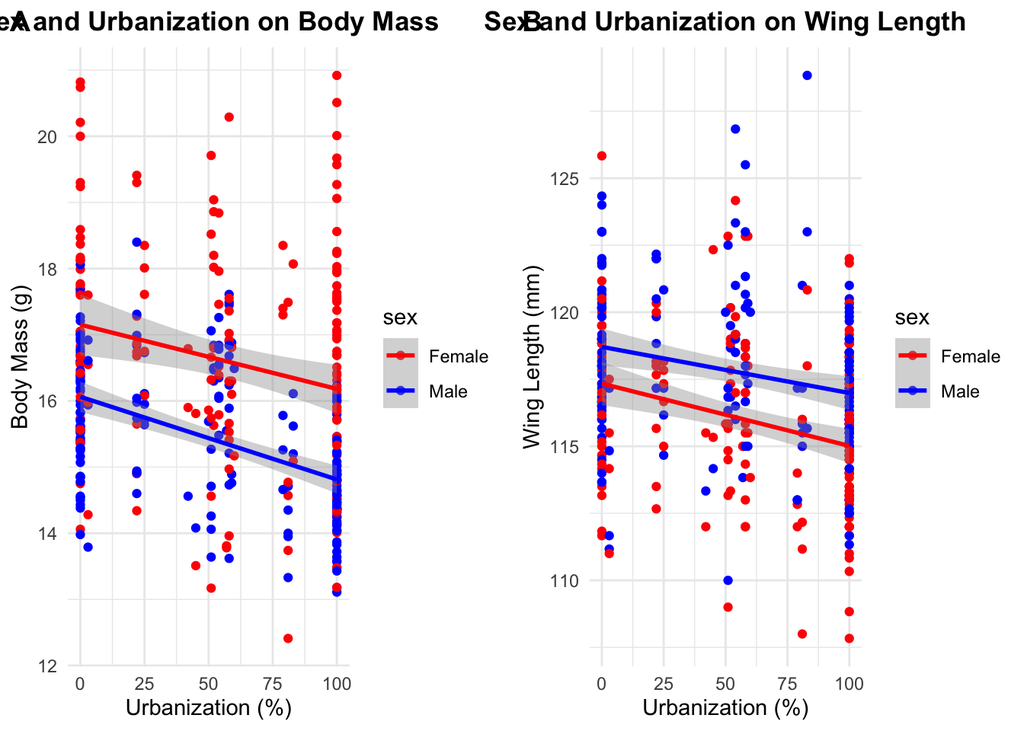

```r
# Create plots
plot1 = ggplot(data=BodySize_data, aes(x=urbanization, y=body.mass, color=sex)) +
  geom_point() +
  geom_smooth(method = "lm", se=TRUE) +
  scale_color_manual(values=c("red","blue")) +
  theme_minimal() +
  theme(plot.title = element_text(hjust=0.5, face="bold")) +
  ggtitle("Sex and Urbanization on Body Mass") +
  labs(x="Urbanization (%)", y="Body Mass (g)")

plot2 = ggplot(data=BodySize_data, aes(x=urbanization, y=wing.length, color=sex)) +
  geom_point() +
  geom_smooth(method = "lm", se=TRUE) +
  scale_color_manual(values=c("red","blue")) +
  theme_minimal() +
  theme(plot.title = element_text(hjust=0.5, face="bold")) +
  ggtitle("Sex and Urbanization on Wing Length") +
  labs(x="Urbanization (%)", y="Wing Length (mm)")

plot_grid(plot1, plot2, labels = "AUTO")
```

# Analysis 2: Regional Comparison

Biological Question: Do swallows North of Beijing have larger body mass compared to swallows South of Beijing?

```r
# Create regions and remove Beijing
BodySize_data$direction = ifelse(BodySize_data$latitude > 39.82022, "North", "South")
Swallows_direction <- filter(BodySize_data, city != "Beijing")

# Fit models
modlog3 = lm(log(body.mass) ~ direction + urbanization, data=Swallows_direction)

# Calculate means and effect sizes
emm.swallow = emmeans(modlog3, specs="direction") %>% as.data.frame()
cohen_d <- emmeans(modlog3, specs="direction") %>%
  eff_size(sigma=sigma(modlog3), edf=df.residual(modlog3))
eta_sq <- eta_squared(modlog3, partial=FALSE)

# Results
Anova(modlog3, type=3)
```

```
## Anova Table (Type III tests)
##
## Response: log(body.mass)
##              Sum Sq  Df    F value    Pr(>F)
## (Intercept)  830.33   1 98351.8568 < 2.2e-16 ***
## direction      0.06   1     7.3457  0.007059 **
## urbanization   0.09   1    10.5566  0.001272 **
## Residuals      2.90 344
## ---
## Signif. codes:  0 '***' 0.001 '**' 0.01 '*' 0.05 '.' 0.1 ' ' 1
```

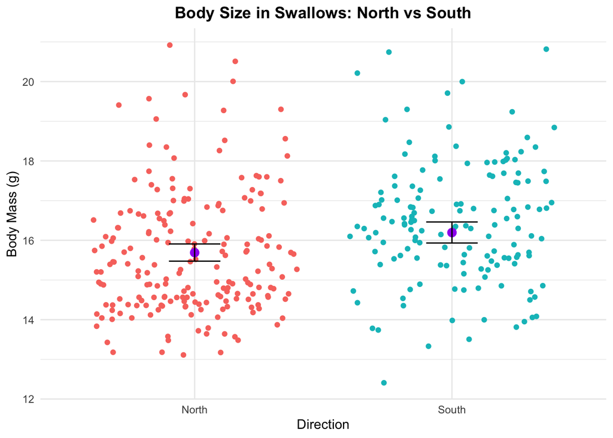

```r
ggplot() +
  geom_jitter(data=Swallows_direction,
              aes(x=direction, y=body.mass, color=direction)) +
  geom_point(data=emm.swallow,
             aes(x=direction, y=exp(emmean)),
             color="purple",
             size=3) +
  geom_errorbar(data=emm.swallow,
                aes(x=direction,
                    ymin=exp(lower.CL),
                    ymax=exp(upper.CL)),
                width=0.2) +
  theme_minimal() +
  theme(legend.position = "none",
        plot.title = element_text(hjust=0.5, face="bold")) +
  ggtitle("Body Size in Swallows: North vs South") +
  labs(x="Direction", y="Body Mass (g)")
```

# Results and Discussion

## Analysis 1: Sex and Urbanization

- No significant interaction between urbanization and sex (parallel regression lines)
- Urbanization shows negative relationship with body size
- Females have greater body mass than males
- Males have longer wing length than females
- Both urbanization and sex effects are significant (p<0.05)

## Limitations

1. Statistical limitations:
   - Wing length data violated normality assumptions
   - Models didn’t fully meet all assumptions
2. Methodological limitations:
   - Simple North/South classification might oversimplify regional variation
   - Cities vary in characteristics (coastal vs. inland)
   - Potential confounding variables not included
   - Regional classification based on Beijing might not reflect true biological zones